# Biomarker Discovery in Untargeted Data: Wines

Pietro Franceschi | pietro.franceschi@fmach.it

```r
library(tidyverse)
library(xcms)
library(MsExperiment)
library(effsize)
library(plotly)
set.seed(123)
```

## Introduction

In the KOMP practical (Day 2) we looked for the metabolites showing a difference between male and female mice. Here we apply the same strategy to the **untargeted** wine dataset we processed on Day 3:

1. organize the data matrix in a tidy way and nest it, one row for each feature
2. run a test on each feature, *on the fly*, with `map()`
3. look at the distribution of the p-values and correct them for multiplicity
4. rank the features by **effect size**, not by p-value
5. go back to the data!

We will address two questions:

- which features are different between **red and white** wines? (two groups: Wilcoxon test and Cohen’s d)
- which features are different among the **varieties**? (more than two groups: ANOVA)

## The data

The output of the preprocessing was saved at the end of the Day 3 practical on retention time correction and feature definition

```r
load("../Day3/processed_wines_data.RData")
```

`DM` is the data matrix (features in rows, samples in columns), `feat` contains the definition of the features (m/z, retention time, …) and the `raw_data_filled` object holds the description of the samples

```r
samples <- sampleData(raw_data_filled) |>
  as_tibble() |>
  select(fname, inj_ord, color, variety, bottle)

samples |>
  count(color, variety)
```

```
## # A tibble: 13 × 3
##    color variety     n
##    <chr> <chr>   <int>
##  1 X     QC          6
##  2 red   cannon      1
##  3 red   frappa      1
##  4 red   lagrei      2
##  5 red   merlot      2
##  6 red   ptnoir      2
##  7 red   sangio      2
##  8 wht   chardo      3
##  9 wht   gewurz      1
## 10 wht   moscat      1
## 11 wht   ptgrig      3
## 12 wht   sauvig      1
## 13 wht   vermen      1
```

We have 20 wines (10 red and 10 white) of 12 varieties, and 6 QCs. Note that several varieties are represented by a single bottle.

We put the data matrix in long format and we add the sample description

```r
DM_long <- DM |>
  as_tibble(rownames = "feature") |>
  pivot_longer(-feature, names_to = "fname", values_to = "into") |>
  mutate(fname = tools::file_path_sans_ext(fname)) |>
  left_join(samples, by = "fname")

DM_long
```

```
## # A tibble: 19,084 × 7
##    feature fname                           into inj_ord color variety bottle
##    <chr>   <chr>                          <dbl> <chr>   <chr> <chr>   <chr>
##  1 FT001   x002_X_QC_X_1_NEG_DDA        391819. x002    X     QC      X
##  2 FT001   x003_X_QC_X_2_NEG_DDA        565995. x003    X     QC      X
##  3 FT001   x004_red_sangio_B_1_NEG_DDA  716180. x004    red   sangio  B
##  4 FT001   x005_red_ptnoir_A_1_NEG_DDA 1131380. x005    red   ptnoir  A
##  5 FT001   x006_red_merlot_A_1_NEG_DDA 1035399. x006    red   merlot  A
##  6 FT001   x007_wht_vermen_A_1_NEG_DDA      NA  x007    wht   vermen  A
##  7 FT001   x008_red_cannon_A_1_NEG_DDA  187783. x008    red   cannon  A
##  8 FT001   x009_wht_chardo_B_1_NEG_DDA      NA  x009    wht   chardo  B
##  9 FT001   x010_wht_chardo_A_1_NEG_DDA      NA  x010    wht   chardo  A
## 10 FT001   x011_red_lagrei_B_1_NEG_DDA 1674084. x011    red   lagrei  B
## # ℹ 19,074 more rows
```

## Feature quality

734 features … are all of them reliable? As we discussed on Day 3, the QCs see only the analytical variability, so a feature which is more variable in the QCs than in the samples does not carry any useful information. We keep only the features with a relative standard deviation (RSD) lower in the QCs than in the samples

```r
rsd <- \(x) sd(x, na.rm = TRUE) / mean(x, na.rm = TRUE)

feat_quality <- DM_long |>
  mutate(class = if_else(variety == "QC", "QC", "sample")) |>
  group_by(feature, class) |>
  summarise(rsd = rsd(into), .groups = "drop") |>
  pivot_wider(names_from = class, values_from = rsd)

good_features <- feat_quality |>
  filter(QC < sample) |>
  pull(feature)
```

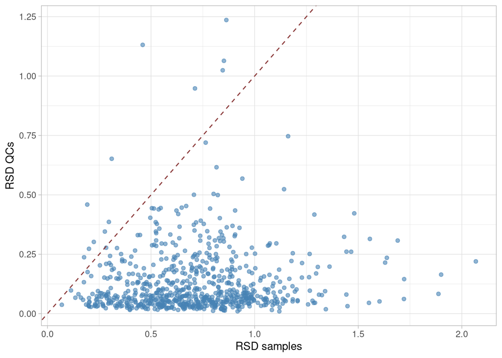

```r
feat_quality |>
  ggplot(aes(x = sample, y = QC)) +
  geom_point(col = "steelblue", alpha = 0.6) +
  geom_abline(slope = 1, intercept = 0, lty = 2, col = "#8B3A3A") +
  labs(x = "RSD samples", y = "RSD QCs") +
  theme_light()
```

722 features out of 734 pass the filter: in this dataset the analytical variability is small compared with the differences among the wines, so only a few features are removed. When the filter removes more, it also means fewer tests and fewer false positives.

## The nested data frame

As in the KOMP practical, we nest the data: one row for each feature, and all the measurements of that feature in a small tibble in the `data` column. The QCs are not needed anymore.

```r
DM_nest <- DM_long |>
  filter(variety != "QC", feature %in% good_features) |>
  nest(data = -feature)

DM_nest
```

```
## # A tibble: 722 × 2
##    feature data
##    <chr>   <list>
##  1 FT001   <tibble [20 × 6]>
##  2 FT002   <tibble [20 × 6]>
##  3 FT003   <tibble [20 × 6]>
##  4 FT004   <tibble [20 × 6]>
##  5 FT005   <tibble [20 × 6]>
##  6 FT006   <tibble [20 × 6]>
##  7 FT007   <tibble [20 × 6]>
##  8 FT008   <tibble [20 × 6]>
##  9 FT009   <tibble [20 × 6]>
## 10 FT010   <tibble [20 × 6]>
## # ℹ 712 more rows
```

```r
DM_nest$data[[1]]
```

```
## # A tibble: 20 × 6
##    fname                           into inj_ord color variety bottle
##    <chr>                          <dbl> <chr>   <chr> <chr>   <chr>
##  1 x004_red_sangio_B_1_NEG_DDA  716180. x004    red   sangio  B
##  2 x005_red_ptnoir_A_1_NEG_DDA 1131380. x005    red   ptnoir  A
##  3 x006_red_merlot_A_1_NEG_DDA 1035399. x006    red   merlot  A
##  4 x007_wht_vermen_A_1_NEG_DDA      NA  x007    wht   vermen  A
##  5 x008_red_cannon_A_1_NEG_DDA  187783. x008    red   cannon  A
##  6 x009_wht_chardo_B_1_NEG_DDA      NA  x009    wht   chardo  B
##  7 x010_wht_chardo_A_1_NEG_DDA      NA  x010    wht   chardo  A
##  8 x011_red_lagrei_B_1_NEG_DDA 1674084. x011    red   lagrei  B
##  9 x012_wht_moscat_A_1_NEG_DDA      NA  x012    wht   moscat  A
## 10 x013_wht_ptgrig_C_1_NEG_DDA      NA  x013    wht   ptgrig  C
## 11 x017_wht_ptgrig_B_1_NEG_DDA      NA  x017    wht   ptgrig  B
## 12 x018_red_ptnoir_B_1_NEG_DDA  381406. x018    red   ptnoir  B
## 13 x019_wht_sauvig_A_1_NEG_DDA      NA  x019    wht   sauvig  A
## 14 x020_wht_gewurz_A_1_NEG_DDA      NA  x020    wht   gewurz  A
## 15 x021_red_merlot_B_1_NEG_DDA 1721708. x021    red   merlot  B
## 16 x022_red_frappa_A_1_NEG_DDA 1038064. x022    red   frappa  A
## 17 x023_wht_ptgrig_A_1_NEG_DDA      NA  x023    wht   ptgrig  A
## 18 x024_red_sangio_A_1_NEG_DDA  746794. x024    red   sangio  A
## 19 x025_red_lagrei_A_1_NEG_DDA 2247568. x025    red   lagrei  A
## 20 x026_wht_chardo_C_1_NEG_DDA      NA  x026    wht   chardo  C
```

### Missing values and log transformation

The nested structure is handy also to process each feature separately. We impute the missing values with the same strategy used for the KOMP data (a random number between 0 and the minimum value measured for that feature) and we log transform the intensities, which in MS are typically right skewed

```r
impute_min <- \(v) {
  nas <- is.na(v)
  v[nas] <- runif(sum(nas), 0, min(v, na.rm = TRUE))
  v
}

DM_nest <- DM_nest |>
  mutate(data = map(data, \(d) d |> mutate(log_into = log10(impute_min(into)))))
```

## Red vs white

### Testing

We run a Wilcoxon test on each feature. Being non-parametric, it does not make assumptions on the distribution of the intensities (and it gives the same result with or without the log transformation).

```r
DM_nest <- DM_nest |>
  mutate(wilcoxon = map(data, \(d) wilcox.test(log_into ~ color, data = d, exact = FALSE)),
         p_color = map_dbl(wilcoxon, \(t) t$p.value))
```

Before looking at single features, we look at the distribution of the p-values. What would it be if there were no difference between red and white wines? We can simulate it by scrambling the intensities of each feature, destroying their association with the color

```r
DM_nest <- DM_nest |>
  mutate(p_perm = map_dbl(data, \(d) {
    d |>
      mutate(log_into = sample(log_into)) |>
      wilcox.test(log_into ~ color, data = _, exact = FALSE) |>
      pluck("p.value")
  }))
```

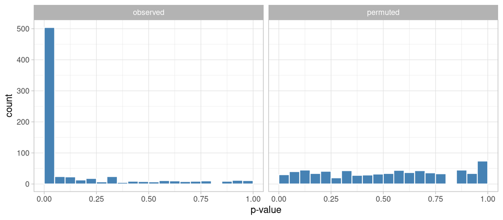

```r
DM_nest |>
  select(feature, observed = p_color, permuted = p_perm) |>
  pivot_longer(-feature, names_to = "data", values_to = "p") |>
  ggplot(aes(x = p)) +
  geom_histogram(breaks = seq(0, 1, 0.05), fill = "steelblue", col = "white") +
  facet_wrap(~data) +
  labs(x = "p-value") +
  theme_light()
```

A clear enrichment of small p-values: red and white wines are different (no surprise!). With permuted data the distribution is flat, as expected when there is no effect.

We correct the p-values for multiplicity (Benjamini-Hochberg) and we calculate the effect size: Cohen’s d on the log intensities, the difference between the two means divided by the pooled standard deviation. Positive values mean higher intensity in red wines.

```r
DM_nest <- DM_nest |>
  mutate(p_color_bh = p.adjust(p_color, method = "BH"),
         cohen = map(data, \(d) cohen.d(log_into ~ factor(color, levels = c("red", "wht")), data = d)),
         d = map_dbl(cohen, \(x) x$estimate))
```

### The markers

We add the description of the features and we keep the ones significant at the 1% level (after correction), sorted by effect size

```r
feat_info <- feat |>
  as_tibble(rownames = "feature") |>
  select(feature, mzmed, rtmed) |>
  mutate(label = sprintf("%s (m/z %.4f, rt %.0f s)", feature, mzmed, rtmed))

color_markers <- DM_nest |>
  filter(p_color_bh < 0.01) |>
  left_join(feat_info, by = "feature") |>
  arrange(desc(abs(d)))

color_markers |>
  select(feature, mzmed, rtmed, p_color_bh, d)
```

```
## # A tibble: 428 × 5
##    feature mzmed rtmed p_color_bh     d
##    <chr>   <dbl> <dbl>      <dbl> <dbl>
##  1 FT708    594.  141.   0.000669 13.6
##  2 FT441    317.  297.   0.000669 11.6
##  3 FT192    179.  375.   0.000669 10.7
##  4 FT519    347.  297.   0.000669 10.7
##  5 FT409    306.  155.   0.000669 10.4
##  6 FT706    593.  182.   0.000669 10.0
##  7 FT606    427.  297.   0.000669  9.75
##  8 FT126    151.  425.   0.000669  9.70
##  9 FT203    183.  105.   0.000669  9.36
## 10 FT443    318.  297.   0.000669  9.33
## # ℹ 418 more rows
```

428 features out of 722 are significant: 255 higher in red wines and 173 higher in white wines.

The volcano plot shows effect size and significance of all the features together. Move the mouse over the points to see which feature they are

```r
volcano <- DM_nest |>
  left_join(feat_info, by = "feature") |>
  mutate(marker = case_when(p_color_bh >= 0.01 ~ "not significant",
                            d > 0 ~ "higher in red",
                            TRUE ~ "higher in white")) |>
  ggplot(aes(x = d, y = -log10(p_color), col = marker, text = label)) +
  geom_vline(xintercept = 0, lty = 2, col = "gray50") +
  geom_point(alpha = 0.7) +
  scale_color_manual(values = c(`higher in red` = "#8B3A3A", `higher in white` = "orange",
                                `not significant` = "gray70"), name = NULL) +
  labs(x = "Cohen's d (log intensity)", y = "-log10(p-value)") +
  theme_light()

ggplotly(volcano, tooltip = "text")
```

[interactive chart not shown]

Look at the top of the volcano: 134 features have exactly the same p-value (0.00018). This is the smallest p-value a Wilcoxon test can give with 10 samples per group, and it is reached by all the features where the red and the white wines do not overlap at all. These features are equally “significant”, but their effect sizes go from 1.6 to 13.6: the p-value cannot be used to rank the markers, the effect size can.

The effect sizes of the 10 features with the largest effect in each direction

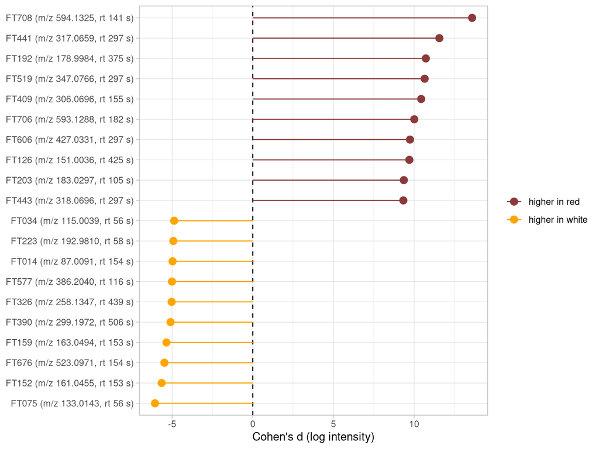

```r
color_markers |>
  mutate(direction = if_else(d > 0, "higher in red", "higher in white")) |>
  slice_max(abs(d), n = 10, by = direction) |>
  mutate(label = fct_reorder(label, d)) |>
  ggplot(aes(x = d, y = label, col = direction)) +
  geom_vline(xintercept = 0, lty = 2) +
  geom_segment(aes(x = 0, xend = d, yend = label)) +
  geom_point(size = 3) +
  scale_color_manual(values = c(`higher in red` = "#8B3A3A", `higher in white` = "orange"), name = NULL) +
  labs(x = "Cohen's d (log intensity)", y = NULL) +
  theme_light()
```

Values of d larger than 10 are suspicious … let’s check how many missing values these features had before imputation

```r
color_markers |>
  slice_head(n = 5) |>
  mutate(na_red = map_int(data, \(d) sum(is.na(d$into[d$color == "red"]))),
         na_white = map_int(data, \(d) sum(is.na(d$into[d$color == "wht"])))) |>
  select(feature, d, na_red, na_white)
```

```
## # A tibble: 5 × 4
##   feature     d na_red na_white
##   <chr>   <dbl>  <int>    <int>
## 1 FT708    13.6      0        8
## 2 FT441    11.6      0        9
## 3 FT192    10.7      0        7
## 4 FT519    10.7      0        9
## 5 FT409    10.4      0        8
```

These features are measured in (almost) all the red wines and missing in (almost) all the white ones: most likely compounds which are not present in white wines (think of the anthocyanins, which give the color to red wines). The difference is real, but the value of d depends on the numbers we used to impute the missing values: a presence/absence marker has, in practice, an “infinite” effect size.

### Back to the data

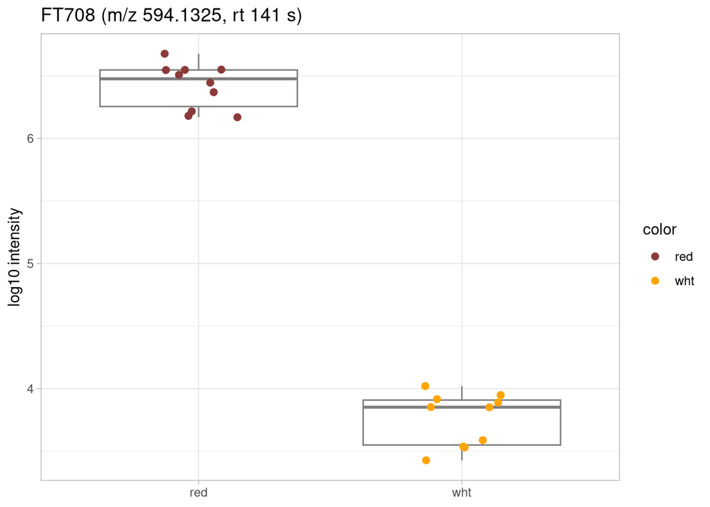

```r
plot_feature <- \(ft, group = color) {
  DM_nest |>
    filter(feature == ft) |>
    unnest(data) |>
    ggplot(aes(x = {{ group }}, y = log_into, col = color)) +
    geom_boxplot(outlier.shape = NA, col = "gray50") +
    geom_jitter(width = 0.15, size = 2) +
    scale_color_manual(values = c(red = "#8B3A3A", wht = "orange")) +
    labs(x = NULL, y = "log10 intensity", title = feat_info$label[feat_info$feature == ft]) +
    theme_light()
}

plot_feature(color_markers$feature[1])
```

And, as we learned on Day 3, the final check is on the raw data:

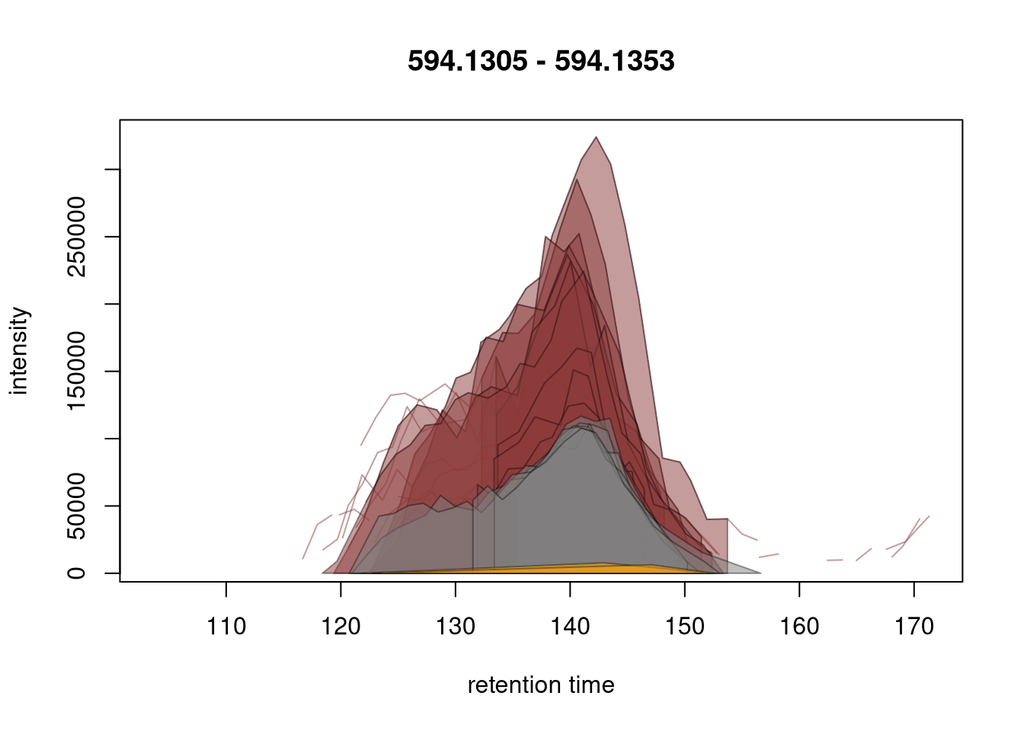

```r
ft_chr <- featureChromatograms(raw_data_filled,
                               features = color_markers$feature[1],
                               expandRt = 15)
sample_colors <- c(red = "#8B3A3A80", wht = "#FFA50080", X = "#80808080")[sampleData(raw_data_filled)$color]
plot(ft_chr, col = sample_colors,
     peakBg = sample_colors[chromPeaks(ft_chr)[, "sample"]])
```

## Differences among varieties

With more than two groups the Wilcoxon test is not anymore an option: we use an **ANOVA**, which tests the null hypothesis that all the group means are equal.

An ANOVA needs replicates within each group to estimate the variability: varieties represented by a single bottle do not contribute to that, so we keep only the varieties with at least two bottles

```r
varieties_ok <- samples |>
  filter(variety != "QC") |>
  count(variety) |>
  filter(n >= 2) |>
  pull(variety)

samples |>
  filter(variety %in% varieties_ok) |>
  count(color, variety)
```

```
## # A tibble: 6 × 3
##   color variety     n
##   <chr> <chr>   <int>
## 1 red   lagrei      2
## 2 red   merlot      2
## 3 red   ptnoir      2
## 4 red   sangio      2
## 5 wht   chardo      3
## 6 wht   ptgrig      3
```

We fit the ANOVA on each feature, and we extract the p-value and an effect size: $\eta^2$, the fraction of the total variance explained by the variety

```r
anova_variety <- \(d) aov(log_into ~ variety, data = d |> filter(variety %in% varieties_ok))

DM_nest <- DM_nest |>
  mutate(anova = map(data, anova_variety),
         anova_table = map(anova, \(m) summary(m)[[1]]),
         p_variety = map_dbl(anova_table, \(t) t[["Pr(>F)"]][1]),
         eta2 = map_dbl(anova_table, \(t) t[["Sum Sq"]][1] / sum(t[["Sum Sq"]])))
```

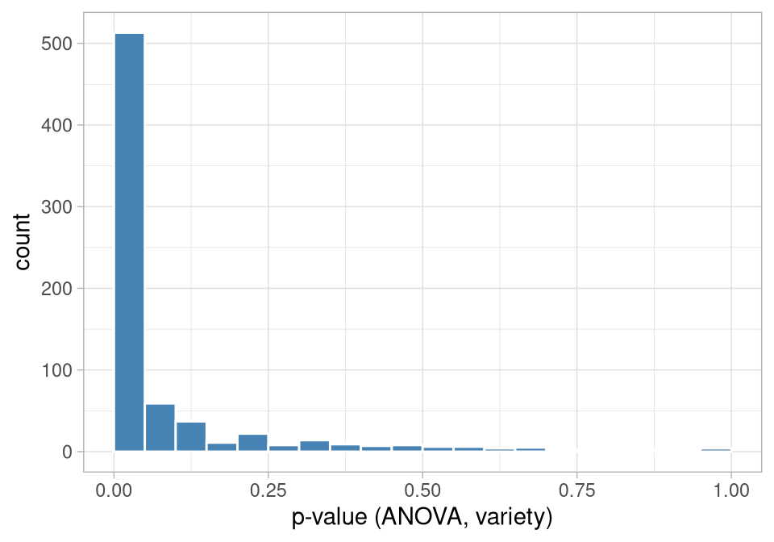

```r
DM_nest |>
  ggplot(aes(x = p_variety)) +
  geom_histogram(breaks = seq(0, 1, 0.05), fill = "steelblue", col = "white") +
  labs(x = "p-value (ANOVA, variety)") +
  theme_light()
```

```r
variety_markers <- DM_nest |>
  mutate(p_variety_bh = p.adjust(p_variety, method = "BH")) |>
  filter(p_variety_bh < 0.01) |>
  left_join(feat_info, by = "feature") |>
  arrange(desc(eta2))

variety_markers |>
  select(feature, mzmed, rtmed, p_variety_bh, eta2)
```

```
## # A tibble: 322 × 5
##    feature mzmed rtmed p_variety_bh  eta2
##    <chr>   <dbl> <dbl>        <dbl> <dbl>
##  1 FT326   258.   439.   0.00000722 0.994
##  2 FT708   594.   141.   0.0000114  0.992
##  3 FT606   427.   297.   0.0000185  0.990
##  4 FT630   451.   352.   0.0000224  0.989
##  5 FT095   137.   277.   0.0000368  0.986
##  6 FT203   183.   105.   0.0000368  0.986
##  7 FT192   179.   375.   0.0000368  0.985
##  8 FT707   594.   215.   0.0000368  0.984
##  9 FT016    97.0  153.   0.0000368  0.984
## 10 FT441   317.   297.   0.0000368  0.984
## # ℹ 312 more rows
```

322 features are significant.

Also here a volcano plot helps, with $\eta^2$ as effect size. Since $\eta^2$ is a fraction of variance it goes from 0 (the variety explains nothing) to 1 (the variety explains all the variability of the feature), and the volcano has only one side

```r
volcano_variety <- DM_nest |>
  left_join(feat_info, by = "feature") |>
  mutate(marker = if_else(feature %in% variety_markers$feature, "variety marker", "not significant")) |>
  ggplot(aes(x = eta2, y = -log10(p_variety), col = marker, text = label)) +
  geom_point(alpha = 0.7) +
  scale_color_manual(values = c(`variety marker` = "steelblue", `not significant` = "gray70"), name = NULL) +
  labs(x = expression(eta^2), y = "-log10(p-value)") +
  theme_light()

ggplotly(volcano_variety, tooltip = "text")
```

[interactive chart not shown]

All the points lie on a single curve! The reason is in the way the ANOVA works: the F statistic can be written as a function of $\eta^2$

$$F = \frac{\eta^2}{1 - \eta^2} \cdot
\frac{N - k}{k - 1}$$

where $N$ is the number of samples and $k$ the number of groups. Since $N$ and $k$ are the same for all the features (here 14 wines of 6 varieties), the p-value is a function of $\eta^2$ alone and the volcano plot does not add any information: ranking the features by p-value or by $\eta^2$ gives exactly the same order. The same would happen in the red vs white volcano with a t-test ($t = d \sqrt{n/2}$ with $n$ samples per group): our first volcano is not a curve only because the Wilcoxon test works on the ranks.

Let’s look at the feature with the largest $\eta^2$ (the plot shows all the varieties, but only the ones with at least two bottles were used in the ANOVA)

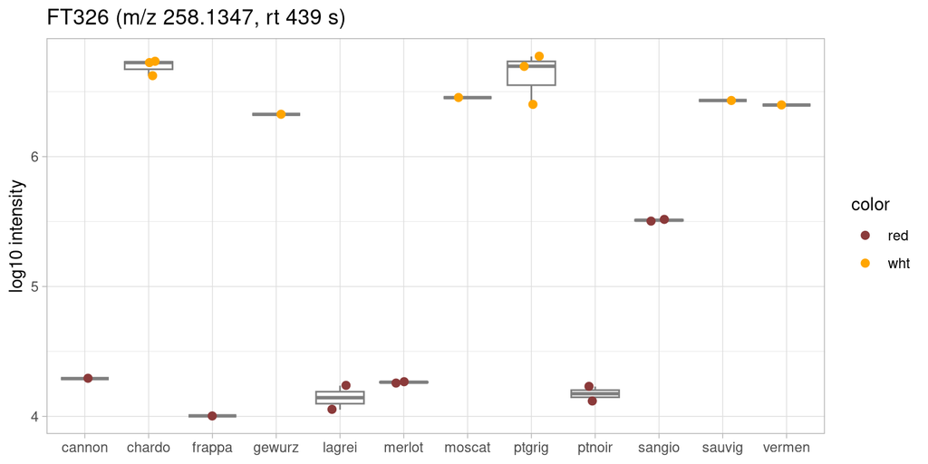

```r
plot_feature(variety_markers$feature[1], group = variety)
```

The ANOVA tells us that *at least one* variety is different, not which one. To know that we need a post-hoc test, for example Tukey’s Honest Significant Differences, which compares all the pairs of varieties correcting for multiplicity

```r
DM_nest |>
  filter(feature == variety_markers$feature[1]) |>
  pull(anova) |>
  pluck(1) |>
  TukeyHSD()
```

```
##   Tukey multiple comparisons of means
##     95% family-wise confidence level
##
## Fit: aov(formula = log_into ~ variety, data = filter(d, variety %in% varieties_ok))
##
## $variety
##                      diff        lwr        upr     p adj
## lagrei-chardo -2.54994171 -2.9341806 -2.1657028 0.0000001
## merlot-chardo -2.43094033 -2.8151792 -2.0467014 0.0000001
## ptgrig-chardo -0.07016285 -0.4138366  0.2735109 0.9696400
## ptnoir-chardo -2.51940058 -2.9036395 -2.1351617 0.0000001
## sangio-chardo -1.18361609 -1.5678550 -0.7993772 0.0000337
## merlot-lagrei  0.11900138 -0.3019113  0.5399140 0.8941282
## ptgrig-lagrei  2.47977886  2.0955399  2.8640178 0.0000001
## ptnoir-lagrei  0.03054113 -0.3903715  0.4514538 0.9997418
## sangio-lagrei  1.36632562  0.9454130  1.7872383 0.0000227
## ptgrig-merlot  2.36077748  1.9765386  2.7450164 0.0000001
## ptnoir-merlot -0.08846025 -0.5093729  0.3324524 0.9658029
## sangio-merlot  1.24732424  0.8264116  1.6682369 0.0000450
## ptnoir-ptgrig -2.44923773 -2.8334766 -2.0649988 0.0000001
## sangio-ptgrig -1.11345325 -1.4976922 -0.7292143 0.0000532
## sangio-ptnoir  1.33578449  0.9148718  1.7566971 0.0000269
```

### Variety or color?

```r
variety_markers |>
  mutate(also_color_marker = feature %in% color_markers$feature) |>
  count(also_color_marker)
```

```
## # A tibble: 2 × 2
##   also_color_marker     n
##   <lgl>             <int>
## 1 FALSE                44
## 2 TRUE                278
```

## Something for you

1. How would you find the features which are different among the varieties *of the same color*? Hint: fit the model `log_into ~ color + variety`: since each variety belongs to a single color, the variety term tests the differences among varieties after the color has been accounted for.
2. Which of the features showing a difference between red and white wines could be annotated with the in-house database of standards of the Day 3 annotation practical?
3. Try a different imputation strategy: how many markers change?

## A possible solution

The nested model: the second row of the ANOVA table is the variety within color

```r
anova_nested <- \(d) aov(log_into ~ color + variety, data = d |> filter(variety %in% varieties_ok))

nested_markers <- DM_nest |>
  mutate(anova_table = map(data, \(d) summary(anova_nested(d))[[1]]),
         p_within = map_dbl(anova_table, \(t) t[["Pr(>F)"]][2]),
         eta2_within = map_dbl(anova_table, \(t) t[["Sum Sq"]][2] / sum(t[["Sum Sq"]]))) |>
  mutate(p_within_bh = p.adjust(p_within, method = "BH")) |>
  filter(p_within_bh < 0.01) |>
  left_join(feat_info, by = "feature") |>
  arrange(desc(eta2_within))

nested_markers |>
  select(feature, mzmed, rtmed, p_within_bh, eta2_within)
```

```
## # A tibble: 21 × 5
##    feature mzmed rtmed p_within_bh eta2_within
##    <chr>   <dbl> <dbl>       <dbl>       <dbl>
##  1 FT672    509.  339.     0.00372       0.943
##  2 FT639    463.  340.     0.00379       0.930
##  3 FT567    382.  155.     0.00561       0.895
##  4 FT590    405.  311.     0.00528       0.874
##  5 FT354    283.  153.     0.00602       0.865
##  6 FT610    431.  274.     0.00775       0.856
##  7 FT673    509.  318.     0.00918       0.833
##  8 FT570    383.  148.     0.00528       0.813
##  9 FT127    151.  337.     0.00798       0.809
## 10 FT711    611.  298.     0.00798       0.771
## # ℹ 11 more rows
```

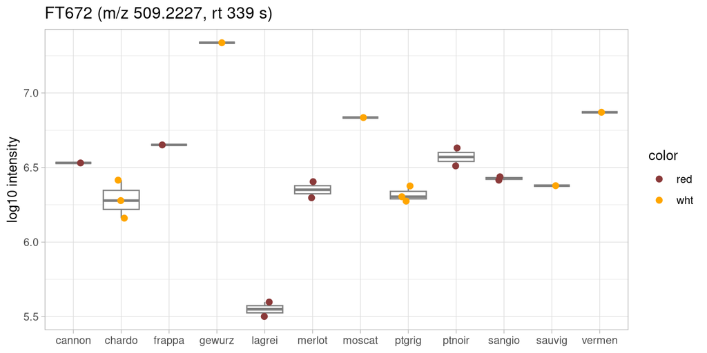

```r
plot_feature(nested_markers$feature[1], group = variety)
```

With only two bottles for most of the varieties, remember that these results are fragile: a “variety marker” could also be a bottle (producer, vintage, …) effect!